# RAPM in R

September 8, 2017

In this post I try to reproduce the RAPM study by [Joe Sill](http://www.sloansportsconference.com/wp-content/uploads/2015/09/joeSillSloanSportsPaperWithLogo.pdf). In the years since he did his paper, a lot of people have used RAPM or built from it so I thought it would be useful to try reproducing it since I haven’t seen any posts online that had the full cross-validation. The data I used for this was play-by-play data scraped from NBA.com and the cleaned data comprises of a unique row for every game stint without a substitution. For each stint, the possessions and scoring are tallied. The goal of RAPM is to estimate individual players’ effect on scoring margin.

Below is how the stints data looks, the columns are players’ NBA.com ID

```r
head(stints[, c(colnames(stints)[1:10], "MARGIN", "POSSESSIONS", "GAME_ID")])
```

```
##   X202331 X2561 X201579 X202362 X201588 X201946 X201571 X201965 X101133
## 1      -1    -1      -1      -1      -1       0       0       0       0
## 2      -1     0      -1      -1      -1      -1       0       0       0
## 3      -1     0      -1       0       0      -1      -1      -1       0
## 4      -1     0      -1       0       0      -1      -1      -1       0
## 5      -1     0      -1       0       0      -1      -1      -1       0
## 6      -1    -1      -1       0       0       0      -1      -1       0
##   X2746     MARGIN POSSESSIONS    GAME_ID
## 1     1   10.81081          37 0041200126
## 2     1 -100.00000           3 0041200126
## 3     1  -28.57143           7 0041200126
## 4     1  -66.66667           3 0041200126
## 5     1   50.00000           4 0041200126
## 6     1  -66.66667           6 0041200126
```

Totals are just aggregated totals, which are useful later when lumping together low-minutes players.

```r
head(totals)
```

```
##          POSS PLAYER_ID      MIN
## X202331 29237    202331 7522.383
## X2561   32040      2561 8179.733
## X201579 30269    201579 7841.600
## X202362 31041    202362 7981.683
## X201588 29799    201588 7692.867
## X201946 14432    201946 3718.767
```

After the data is prepared, I can start preparing parameters and cross validation. In the RAPM paper, he mentions three parameters he tried out to prevent overfitting: 1. a minutes-cutoff for aggregating low-minutes players, 2. a year-weighting for discounting older observations, and 3. different lambda for the regularized regression.

```r
cutoff_param<-c( 100, 1000)
year_param<-c(.25, .5)
lambda_param<-c( 2000, 100, 10 )
```

I also specify the folds that I use. I’m fitting the models on 2012/13, 2013/14, 2014/15 data so it’s important that the out-of-fold data is the 14/15 data so that the year-weights make sense.

```r
nfolds<-10
folds<-replicate(nfolds, sample(which(stints$Year==2015 & stints$POSSESSIONS>0),size=20000, replace=F)) #include some of 15 data in fold
folds<-rbind(folds,replicate(nfolds, which(stints$Year<2015 & stints$POSSESSIONS>0)))
outfolds<-sapply(1:ncol(folds),function(x) setdiff(which(stints$POSSESSIONS>0), folds[,x])) #rest of 15 out of fold
```

Finally, I wrote a loop for cross validation. Glmnet allows you to specify multiple lambdas so I wrap that function with a loop for the testGrid parameters. It’s pretty ugly but it gets the job done. Overall, what it’s doing is retraining a regularized regression model with different parameter specifications and then storing the OOF CV errors in “fitList”. In the end, fitList will hold the mean 10-fold CV-error for each parameter combo of testGrid and so it will be of length testGrid.

```r
testGrid<-expand.grid(cutoff_param=cutoff_param,year_param=year_param)

cl<-makeCluster(2, type = "SOCK")
registerDoSNOW(cl)

#for each parameter combo
fitList<-  foreach(k=1:nrow(testGrid), .packages = c("glmnet")) %dopar% {

  #specify parameters and fit model on each CV fold

  players<-paste("X", totals$PLAYER_ID[totals$MIN>=testGrid$cutoff_param[k]]  , sep="")
  stints$XOTHER<-rowSums(stints[, grepl("X", colnames(stints) ) & !grepl("OTHER", colnames(stints))& !colnames(stints)%in% players ])
  indVars<- c( "XOTHER",  players)

  errors<-lapply(1:nfolds, function(x){
    fit<-glmnet( x=as.matrix(stints[folds[,x],indVars ]),
                 y=stints$MARGIN[folds[,x]],
                 weights=testGrid$year_param[k]^(max(stints$Year)-stints$Year[folds[,x]])*stints$POSSESSIONS[folds[,x]],
                 alpha=0,
                 # standardize=F,
                 lambda = lambda_param)

    #(out of fold errors are RMSE of predicted margins to actual margin, weighted by possessions)--I'm not aggregating by game here, don't think it shoud matter, just will make actual RMSE values not relevant on their own

    errors<-(predict(fit, newx=data.matrix(stints[outfolds[, x], indVars] ))*stints$POSSESSIONS[outfolds[,x]] -
               stints$MARGIN[outfolds[,x]]*stints$POSSESSIONS[outfolds[,x]] )^2
    errors<-sqrt(colMeans(errors))
    errors
  })

  #return parameters and aggregated results of OOF error for current testGrid row
  cvm<-sapply(1:length(lambda_param), function(x) mean(sapply(errors, `[[`, x)))
  cvsd<-sapply(1:length(lambda_param), function(x) sd(sapply(errors, `[[`, x)))
  fit<-list();fit$cvm<-cvm;fit$cvsd<- cvsd;fit$lambda<-lambda_param;fit$year_param<-testGrid$year_param[k];fit$cutoff_param<-testGrid$cutoff_param[k]
  fit
}
```

I’m sure Joe Sills code is way better but mine works too.. anyway, with fitList I can look at the errors of each parameter and extract the optimal paramater combos,

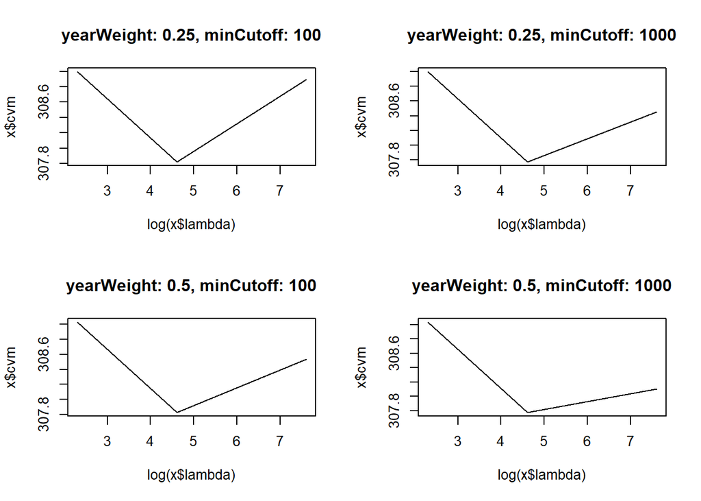

```r
par(mfrow=c(2, 2))
for(x in fitList){
  plot(x$cvm~log(x$lambda), type="l", main=paste0(c("yearWeight: ", x$year_param, ", minCutoff: ", x$cutoff_param), collapse=""))
}
```

```r
params<-fitList[[which.min(sapply(fitList, function(x) min(x$cvm)))]]
params
```

[output not shown]

As you can see, regularization (lambda) makes the biggest difference of the parameters. One weird thing is that I am getting a different optimal lambda (~100) versus the paper which was getting 2000. It could be from training on different years or maybe I’m doing something wrong. After getting the optimal parameters, I then refit the model on all the 2013-15 data using the optimal parameters. I didn’t include the code for that, but it just is done by running glmnet on all the data. Below are the player coefficients. My coefficients are different than the ones I see normally, however when testing this on a test set I had good results. I’m a bit confused about that and it’s possible they are using lambda=0 for the RAPM rankings I see online that have high coefficients. Finally, one thing I don’t like about RAPM is it seems to over-inflate players on good teams, specifically someone like Draymond Green–I refuse to believe he’s even a top 20 player. I guess models don’t have irrational burning hatred for players like I do though..

```
##       PLAYER_ID      RAPM  POSS       MIN           Name
##  1:      201939 1.4651995 41518 10060.900  Stephen Curry
##  2:      203110 1.3860297 27284  6581.500 Draymond Green
##  3:        2594 1.3044996 32202  8038.283    Kyle Korver
##  4:        2544 1.2622279 42206 10840.983   LeBron James
##  5:      101108 1.2343768 34146  8504.783     Chris Paul
##  6: (Intercept) 1.2333799    NA        NA             NA
##  7:      201988 1.1565989 14137  3478.483    Patty Mills
##  8:      203482 1.1531874 11703  2876.550   Kelly Olynyk
##  9:      202691 1.0987467 40068  9771.600  Klay Thompson
## 10:      201142 1.0930478 34448  8452.317   Kevin Durant
## 11:        1938 1.0409870 23645  5808.517  Manu Ginobili
## 12:      202695 1.0409559 29961  7527.567  Kawhi Leonard
## 13:      200755 1.0379849 27246  6736.350      JJ Redick
## 14:      201980 0.9814472 30119  7564.383    Danny Green
## 15:        2440 0.9536419 28374  7038.567    Matt Barnes
## 16:        2730 0.9402543 29414  7273.167  Dwight Howard
## 17:      201168 0.9305847 21300  5325.250 Tiago Splitter
## 18:      201588 0.9235070 29799  7692.867    George Hill
## 19:      101106 0.9097091 19951  4904.500   Andrew Bogut
## 20:      201933 0.9079464 36117  9011.300  Blake Griffin
```

The last thing I did was predicted on 2016 test data. On the training data for 2015 I was getting around .25 R^2, and I got around .17 R^2 on the test set of 2016, aggregating the data by GAME_ID. Overall, I think all of this was useful because seeing as the original RAPM paper was from a while ago, it might be the case that different parameters are now better. In the future I want to try adding more variables and experiment more with the model. You can view the code for this and the scripts for getting the PBP stints data on [Github](https://github.com/dlm1223/nba-pbp-data)